# 7 Beta diversity

```r
load("data/data.Rdata")
```

## 7.1 Diversity calculations

```r
beta_div <- list()

n=0
for (strategy in strategies){
  n=n+1
  bin_counts_norm_filt_strategy <- bin_counts_norm_filt %>%
    filter(overall_strategy == {{strategy}}) %>%
    select(secondary_cluster,sample,read_count) %>%
    pivot_wider(names_from = "sample", values_from = "read_count", values_fn = sum) %>%
    column_to_rownames(var="secondary_cluster")

   cluster_tree_strategy <- keep.tip(cluster_tree, tip=rownames(bin_counts_norm_filt_strategy))

    beta_q0n <- bin_counts_norm_filt_strategy %>%
      hillpair(., q=0, metric="C") %>% as.dist()

    beta_q1n <- bin_counts_norm_filt_strategy %>%
      hillpair(., q=1, metric="C")

    beta_q1p <- bin_counts_norm_filt_strategy %>%
      hillpair(., q=1, metric="C", tree = cluster_tree_strategy)

  beta_div_strategy <- list(q0n=beta_q0n,q1n=beta_q1n,q1p=beta_q1p)
  beta_div[[n]] <- beta_div_strategy
}

names(beta_div) <- strategies
```

The distance matrices of the different strategies list the samples in different orders (only `single_coverage` and the three coassemblies share the same order). `protest()` compares the configurations row by row, so all matrices must be reindexed to a common sample order **before** the NMDS ordinations are computed. Otherwise the Procrustes comparison relates different samples to each other.

```r
# Common sample order (sorted sample names)
sample_order <- sort(labels(beta_div[[1]]$q0n))

align_dist <- function(d, ord) {
  stopifnot(setequal(labels(d), ord))
  as.dist(as.matrix(d)[ord, ord])
}

beta_div <- lapply(beta_div, function(x) lapply(x, align_dist, ord = sample_order))

# Every matrix must now carry the same labels in the same order
stopifnot(all(sapply(beta_div, function(x) all(sapply(x, function(d) identical(labels(d), sample_order))))))
save(beta_div,file="results/beta_diversity.Rdata")
```

## 7.2 Procrustes analysis

Non-metric multidimensional scaling (NMDS, `metaMDS`, k = 2, `trymax` = 999, seed 1) was computed on the (aligned) distance matrix of each strategy and every pair of ordinations was compared with a Procrustes test (`protest`, 999 permutations). The statistic reported is the **Procrustes correlation** `sqrt(1 - m12^2)` (`protest()$t0`; 1 = identical configurations), together with the permutation p-value. The Procrustes scale factor is not a measure of similarity and is not shown. The computation is heavy and is stored in `results/beta_procrustes.Rdata`.

```r
load("results/beta_diversity.Rdata")

metrics <- c(q0n="Richness (q0)", q1n="Neutral (q1)", q1p="Phylogenetic (q1 + tree)")

# Pairwise Procrustes correlation (lower triangle computed, matrix symmetric) and permutation p
procrustes_mat <- list(); procrustes_p <- list(); nmds_list <- list()
for(metric in names(metrics)){
  nmds <- list()
  for(strategy in strategies){
    set.seed(1)
    nmds[[strategy]] <- metaMDS(beta_div[[strategy]][[metric]], trymax = 999, k=2, trace=0)
  }
  cor_mat <- matrix(1, length(strategies), length(strategies), dimnames=list(strategies, strategies))
  p_mat <- matrix(NA_real_, length(strategies), length(strategies), dimnames=list(strategies, strategies))
  for(i in seq_along(strategies)){
    for(j in seq_along(strategies)){
      if(i < j){
        set.seed(1)
        pt <- protest(nmds[[i]], nmds[[j]], permutations = 999)
        cor_mat[i,j] <- cor_mat[j,i] <- pt$t0
        p_mat[i,j] <- p_mat[j,i] <- pt$signif
      }
    }
  }
  procrustes_mat[[metric]] <- cor_mat
  procrustes_p[[metric]] <- p_mat
  nmds_list[[metric]] <- sapply(nmds, function(x) x$stress)
}
save(procrustes_mat, procrustes_p, nmds_list, file="results/beta_procrustes.Rdata")
```

### 7.2.1 Procrustes correlation heatmaps

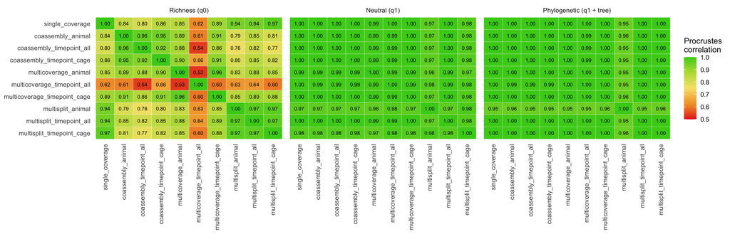

```r
load("results/beta_procrustes.Rdata")

# Strategies grouped by bioinformatic strategy
strategy_order <- c("single_coverage",
                    "coassembly_animal","coassembly_timepoint_all","coassembly_timepoint_cage",
                    "multicoverage_animal","multicoverage_timepoint_all","multicoverage_timepoint_cage",
                    "multisplit_animal","multisplit_timepoint_all","multisplit_timepoint_cage")
metric_labels <- c(q0n="Richness (q0)", q1n="Neutral (q1)", q1p="Phylogenetic (q1 + tree)")

procrustes_long <- purrr::map_dfr(names(procrustes_mat), function(m){
  as.data.frame(as.table(procrustes_mat[[m]])) %>%
    rename(v1=Var1, v2=Var2, correlation=Freq) %>%
    mutate(metric=metric_labels[[m]])
}) %>%
  mutate(v1=factor(v1,levels=strategy_order), v2=factor(v2,levels=rev(strategy_order)),
         metric=factor(metric,levels=metric_labels))

procrustes_long %>%
  ggplot(aes(x=v1,y=v2,fill=correlation)) +
    geom_tile(colour = "white") +
    geom_text(aes(label=sprintf("%.2f",correlation)), size=2.5) +
    scale_fill_gradientn(colours=c("#e51f1f","#f2a134","#f7e379","#bbdb44","#44ce1b"), limits=c(0.5,1)) +
    facet_wrap(~metric) +
    theme_minimal() +
    theme(axis.text.x = element_text(angle = 90, vjust = 0.5, hjust=1)) +
    labs(x=NULL,y=NULL,fill="Procrustes\ncorrelation")
```

```r
# Range of permutation p-values (off-diagonal)
sapply(procrustes_p, range, na.rm=TRUE)
```

```
       q0n   q1n   q1p
[1,] 0.001 0.001 0.001
[2,] 0.001 0.001 0.001
```

After aligning the samples, the community ordinations of the ten strategies are almost identical for neutral (q1) and phylogenetic (q1 + tree) diversity (Procrustes correlations 0.95-1.00 for all pairs). Richness (q0) is less congruent, mainly because of `multicoverage_timepoint_all`, whose ordination correlates less with the other strategies. All permutation p-values are 0.001 (the minimum with 999 permutations). Note that previous versions of this chapter compared ordinations whose samples were in different order and are invalid (kept as `results/beta_diversity_misaligned_OLD.Rdata`).